# DS_Lin slides

## Machine Learning for Engineering

## Dynamical System: Linear Case

### Instructor: Daning Huang

$$ \newcommand\norm[1]{{\left\lVert #1 \right\rVert}} \newcommand{\bR}{\mathbb{R}} \newcommand{\vf}{\mathbf{f}} \newcommand{\vg}{\mathbf{g}} \newcommand{\vv}{\mathbf{v}} \newcommand{\vw}{\mathbf{w}} \newcommand{\vx}{\mathbf{x}} \newcommand{\vy}{\mathbf{y}} \newcommand{\vA}{\mathbf{A}} \newcommand{\vB}{\mathbf{B}} \newcommand{\vU}{\mathbf{U}} \newcommand{\vV}{\mathbf{V}} \newcommand{\vW}{\mathbf{W}} \newcommand{\vX}{\mathbf{X}} \newcommand{\vtf}{\boldsymbol{\phi}} \newcommand{\vty}{\boldsymbol{\psi}} \newcommand{\vtF}{\boldsymbol{\Phi}} \newcommand{\vtS}{\boldsymbol{\Sigma}} \newcommand{\vtL}{\boldsymbol{\Lambda}} \newcommand{\cF}{\mathcal{F}} \newcommand{\cK}{\mathcal{K}} \newcommand{\Im}{\mathrm{Im}} \newcommand{\Wr}{\mathbf{W}_{\mathrm{reach}}} \newcommand{\Wc}{\mathbf{W}_{\mathrm{contr}}} \newcommand{\Wo}{\mathbf{W}_{\mathrm{obs}}} \newcommand{\cA}{\mathcal{A}} \newcommand{\cL}{\mathcal{L}} \newcommand{\cP}{\mathcal{P}} \newcommand{\cQ}{\mathcal{Q}} \newcommand{\cR}{\mathcal{R}} \newcommand{\rO}{{\color{red}O}} $$

## TODAY: Dynamical System

- Concepts in linear systems
- Model reduction for linear systems: balanced truncation and balanced POD

### References:

- A.C. Antoulas, Approximation of Large-Scale Dynamical Systems
- emgr - EMpirical GRamian Framework

## Definitions

Standard linear (time-invariant) system $$ \begin{align*} \dot{x} &= Ax+Bu \\ y &= Cx+Du \end{align*} $$ with initial condition $x(0)=x_0$

- $x\in R^N$: State vector, possibly **very high dimensional**
- $y\in R^q$: Observation vector, typically $q\ll N$
- $u\in R^p$: Control inputs, typically $p\ll N$

### Solutions

$$ x(t) = \underbrace{\exp(At)x_0}_{\text{Initial response}} + \underbrace{\int_0^t \exp(A(t-\tau))Bu(\tau) d\tau}_{\text{Forced response}} $$

### Coordinate Transformation

For any full-rank matrix $T\in R^{N\times N}$, one can transform $$ x'=Tx $$ to obtain an equivalent system $$ \begin{align*} \dot{x}' &= A'x'+B'u \\ y &= C'x'+D'u \end{align*} $$ where $$ A'=TAT^{-1},\ B'=TB,\ C'=CT^{-1},\ D'=D $$

## Controllability and Observability - Definitions

> For convenience, we ignore $D$ in the following.

### Reachability and Controllability

A state $x^*$ is **reachable**

- From $x=0$, and given
- a certain input $u(t)$ (of finite energy)
- a finite time $T$
- The state becomes $x^*$.

Denote the set of reachable states as $\Wr$.

A state $x^*$ is **controllable**

- From $x=x^*$, and given
- a certain input $u(t)$ (of finite energy)
- a finite time $T$
- The state becomes $0$.

Denote the set of controllable states as $\Wc$.

For example, if a linear system is $$ \begin{align} \begin{bmatrix}\dot{x}^{(1)} \\ \dot{x}^{(2)}\end{bmatrix} &= \begin{bmatrix}A^{(1,1)} & A^{(1,2)} \\ \rO & A^{(2,2)}\end{bmatrix} \begin{bmatrix}x^{(1)} \\ x^{(2)}\end{bmatrix} + \begin{bmatrix}B^{(1)} \\ \rO\end{bmatrix}u \\ y &= \begin{bmatrix}C^{(1)} & C^{(2)}\end{bmatrix} \begin{bmatrix}x^{(1)} \\ x^{(2)}\end{bmatrix} \end{align} $$ Then $x^{(2)}$ are not controllable, because

- $u$ cannot affect $x^{(2)}$ directly, or
- indirectly through $x^{(1)}$

A system is completely controllable if there is **no** transformation such that the system is equivalent to the previous form with

- $A^{(2,1)}=\rO$, $B^{(2)}=\rO$.
- Controllability is a property of only $(A,B)$.

### Observability

A state $x^*$ is **unobservable**, if

- Starting from $x(0)=x^*$
- for any $t$
- and $u(t)=0$
- Observation $y(t)=0$

For example, if a linear system is $$ \begin{align} \begin{bmatrix}\dot{x}^{(1)} \\ \dot{x}^{(2)}\end{bmatrix} &= \begin{bmatrix}A^{(1,1)} & \rO \\ A^{(2,1)} & A^{(2,2)}\end{bmatrix} \begin{bmatrix}x^{(1)} \\ x^{(2)}\end{bmatrix} + \begin{bmatrix}B^{(1)} \\ B^{(2)}\end{bmatrix}u \\ y &= \begin{bmatrix}C^{(1)} & \rO\end{bmatrix} \begin{bmatrix}x^{(1)} \\ x^{(2)}\end{bmatrix} \end{align} $$ Then $x^{(2)}$ are not observable, because

- $y$ cannot measure $x^{(2)}$ directly, or
- indirectly through $x^{(1)}$

A system is completely observable if there is **no** transformation such that the system is equivalent to the previous form with

- $A^{(1,2)}=\rO$, $C^{(2)}=\rO$.
- Observability is a property of only $(A,C)$.
- This is a **dual** to Controllability

Consider all combinations: (un)controllable $\times$ (un)observable, a linear system can be transformed to $$ \begin{align} \begin{bmatrix}\dot{x}^{(1)} \\ \dot{x}^{(2)} \\ \dot{x}^{(3)} \\ \dot{x}^{(4)}\end{bmatrix} &= \begin{bmatrix} A^{(1,1)} & A^{(1,2)} & A^{(1,3)} & A^{(1,4)} \\ \rO & A^{(2,2)} & \rO & A^{(2,4)} \\ \rO & \rO & A^{(3,3)} & A^{(3,4)} \\ \rO & \rO & \rO & A^{(4,4)}\end{bmatrix} \begin{bmatrix}x^{(1)} \\ x^{(2)} \\ x^{(3)} \\ x^{(4)}\end{bmatrix} + \begin{bmatrix}B^{(1)} \\ B^{(2)} \\ \rO \\ \rO\end{bmatrix}u \\ y &= \begin{bmatrix}\rO & C^{(2)} & \rO & C^{(4)}\end{bmatrix} \begin{bmatrix}x^{(1)} \\ x^{(2)} \\ x^{(3)} \\ x^{(4)}\end{bmatrix} \end{align} $$

- This is the **Canonical Structure Theorem** (Kalman 1961)
- Typically we care about **Part (2)**, that is completely controllable and completely observable.
- The rest is
  - uncontrollable (i.e., cannot do anything to it), and/or
  - unobservable (i.e., cannot measure what is done)

### Example

In the following we will deal with a linear system of 4 states, 1 input, and 1 output. Printed as one matrix $$ \begin{bmatrix} A & B \\ C & D \end{bmatrix} $$

```python
sys_print((A,B,C))  # The LTI system
```

```
[[  0.8   0.  -16.   -7.2  -0.8]
 [  0.4  -2.   -1.5  -2.1  -1.4]
 [  0.    0.   -3.    0.    0. ]
 [  1.2   0.   -4.   -5.8  -0.2]
 [  1.    2.   -1.   -3.    0. ]]
```

```python
sys_print((_A,_B,_C))  # The system is transformed from this one
                       # Note the canonical structure
```

```
[[-1.  0. -6. -3.  1.]
 [ 0. -2. -2. -2.  3.]
 [ 0.  0. -3.  0.  0.]
 [ 0.  0.  0. -4.  0.]
 [ 0. -1.  0.  1.  0.]]
```

## Controllability and Observability - Characterization

### Useful Fact

For $\exp(At)$ in linear system solution:

By Taylor series expansion $$ \exp(At) = I + tA + \frac{t^2}{2}A^2 + \cdots + \frac{t^N}{N!}A^N + \cdots $$

But for any $K\geq N$, $A^K = \sum_{i=0}^{N-1} c_i A^i$ for some $c_i$. [Cayley–Hamilton theorem](https://en.wikipedia.org/wiki/Cayley%E2%80%93Hamilton_theorem)

Then we have an **exact** and **finite** expression: $$ \exp(At) = \sum_{i=0}^{N-1} \alpha_i(t) A^i $$ for certain coefficients $\alpha_i(t)$.

### Reachability

Revisit the linear system solution with $x_0=0$ and any $u(t)$ $$ \begin{align*} x(t) &= \int_0^t \exp(A(t-\tau))Bu(\tau) d\tau = \int_0^t \exp(As)Bu(t-s) ds \\ &= \int_0^t \left(\sum_{i=0}^{N-1} \alpha_i(s) A^i\right)Bu(t-s) ds \\ &= \sum_{i=0}^{N-1} \beta_i(t) A^iB \end{align*} $$ where $$ \beta_i(t) = \int_0^t \alpha_i(s)u(t-s) ds $$

This means a reachable state $x(t)$ must be a linear combination of the following matrices $$ \cR(A,B) = [B,AB,\cdots,A^{N-1}B] $$ Hence $\cR$ is the reachability matrix and $$ \Wr = \Im \cR(A,B) $$

- Complete reachable $\Leftrightarrow$ rank $\cR=N$

Also note that if we look at an equivalent system with transformation $T$, $$ \cR(A',B') = [\cdots,(A')^iB',\cdots] = [\cdots,(TAT^{-1})^iTB,\cdots] = [\cdots,TA^iB,\cdots] = T\cR(A,B) $$ so $$ \Im \cR(A',B') = \Im \cR(A,B) $$ so $\cR$ is **coordinate-independent**.

### Controllability

Now we start from $x_0\neq 0$ and want to drive the states to 0 at time $t$.

$$ \begin{align*} x(t) &= \exp(At)x_0 + \int_0^t \exp(A(t-\tau))Bu(\tau) d\tau \\ x(t)-\exp(At)x_0 \equiv x_d &= \int_0^t \exp(A(t-\tau))Bu(\tau) d\tau \\ &= \sum_{i=0}^{N-1} \beta_i(t) A^iB \end{align*} $$

Then for $x_0$ to be controllable, it must be a linear combination of $\cR(A,B)$ as well. So $$ \Wc=\Im\cR(A,B) = \Wr $$

```python
R = comp_R(A, B)  # The controllability matrix
u, s, vh = np.linalg.svd(R)
print(s)        # This has two non-zero SVs
CC = u[:,:2].T  # Controllable subspace
UC = u[:,2:].T  # Uncontrollable
```

```
[1.3732e+01 9.6594e-01 3.4139e-16 5.7619e-32]
```

```python
Tinv = np.vstack([CC, UC]).T
sys = sys_transform((A,B,C), Tinv)
sys_print(sys)
```

```
[[-2.0023e+00  2.2992e-02 -2.9439e+00 -3.1023e+00  1.4738e+00]
 [-9.8276e-02 -9.9775e-01  8.1516e+00  1.6267e+01 -6.8406e-01]
 [ 1.2364e-16  1.0854e-15 -4.0000e+00  6.2172e-15 -1.3878e-16]
 [ 2.7453e-32  2.4101e-31 -2.2204e-16 -3.0000e+00 -3.0815e-32]
 [-2.0141e+00  4.6205e-02  3.1530e+00  1.0000e+00  0.0000e+00]]
```

### Controllability Gramian

Beyond knowing whether a state is controllable, we can also **quantify** the level of controllability

Suppose we try to find the necessary control to reach $x_d$ $$ \begin{align*} x_d &= \int_0^t \exp(A(t-\tau))Bu(\tau) d\tau \\ &= \lim_{N\rightarrow\infty} \sum_{i=0}^N \exp(A(t-\tau_i))Bu(\tau_i)\Delta\tau \\ &= \lim_{N\rightarrow\infty} LU \end{align*} $$ where $$ L = [\cdots,\exp(A(t-\tau_i))B\Delta\tau,\cdots],\quad U^T=[\cdots,u(\tau_i)^T,\cdots] $$

For finite $N$, least-norm solution $$ U = V\Sigma^{-1} W^T x_d $$ where $L = W\Sigma V^T$.

Then $$ \int_0^t \norm{u(\tau)}^2 d\tau \approx U^TU\Delta\tau = x_d^T (W \Sigma^{-2} W^T\Delta\tau) x_d = x_d^T (LL^T)^{-1}\Delta\tau x_d $$ since $LL^T = W\Sigma^2 W^T$

Note that $$ (LL^T)^{-1}\Delta\tau = \left(\sum_{i=0}^{N_t} \exp(A(t-\tau_i))BB^T\exp(A^T(t-\tau_i))\right)^{-1}\Delta\tau^{-1} $$

Taking the limit of the inverse $$ \cP = \lim_{\Delta\tau\rightarrow 0} (LL^T)\Delta\tau = \int_0^t \exp(A(t-\tau))BB^T\exp(A^T(t-\tau))d\tau $$

By change of variable, we can also write, $$ \cP(t) = \int_0^t \exp(A\tau)BB^T\exp(A^T\tau)d\tau $$ assuming real-valued $(A,B)$.

The total energy for controlling a certain state $x_d$ is $$ \int_0^t \norm{u(\tau)}^2 d\tau = x_d^T \cP^{-1} x_d $$

In other words, $\cP^{-1}$ characterizes the energy needed to control a state.

One critical property of $\cP$ is its positive semi-definiteness.

For $\forall x\neq 0$ $$ x^T\cP x = \int_0^t x^T\exp(A\tau)BB^T\exp(A^T\tau)xd\tau = \int_0^t \norm{B^T\exp(A^T\tau)x}^2d\tau \geq 0 $$

Over a unit magnitude, the state that requires the least energy to control satisfies $$ \max_{\norm{x}=1} \norm{x}_{\cP^{-1}} = \lambda_\max^{-1} $$ where $\lambda_\max$ is the maximum eigenvalue of $\cP$.

```python
cP = comp_cP_inf(A, B)  # The controllability Gramian
w, v = spl.eigh(cP)
print(w)      # This has two non-zero EVs; ascending order
tmp = v[:,::-1].T
CC = tmp[:2]  # Controllable subspace
UC = tmp[2:]  # Uncontrollable
```

```
[-5.3747e-18  0.0000e+00  2.7234e-02  7.8027e-01]
```

```python
Tinv = np.vstack([CC, UC]).T
sys = sys_transform((A,B,C), Tinv)
sys_print(sys)
```

```
[[-1.6444e+00 -4.2188e-01 -1.1776e+01 -7.0455e+00  1.6019e+00]
 [-5.4315e-01 -1.3556e+00  1.1644e+01  5.0474e+00  2.7173e-01]
 [ 0.0000e+00  0.0000e+00 -3.0000e+00  0.0000e+00  0.0000e+00]
 [-4.1971e-16  3.3005e-15  1.4211e-14 -4.0000e+00  4.7184e-16]
 [-1.6856e+00 -1.1035e+00  1.0000e+00  3.1530e+00  0.0000e+00]]
```

### Observability

Using a similar approach, we can characterize the Observability.

If we want $x_0$ to be observable, then $$ y(t) = C\exp(At)x_0 \neq 0 $$ Knowing $\exp(At)=\sum_{i=0}^{N-1}\alpha_i(t)A^i$, then $x_0$ should not be in the null spaces of $CA^i$, $i=0,1,\cdots,N-1$

In other words, $x_0$ must be in the row space of the **Observability matrix** $$ Q=\begin{bmatrix} C \\ CA \\ \vdots \\ CA^{N-1} \end{bmatrix} $$

### Observability Gramian

Now, suppose we have measurements $y(\tau_i)$ over interval $[0,t]$ with step size $\Delta \tau$, and want to infer $x_0$, $$ Y = Mx_0 $$ where $$ Y = \begin{bmatrix} \vdots \\ y(\tau_i) \\ \vdots \end{bmatrix},\quad M = \begin{bmatrix} \vdots \\ C\exp(A\tau_i) \\ \vdots \end{bmatrix} $$

Then $$ x_0 = (M^TM)^{-1}M^TY $$ with $$ Q = M^TM = \sum_{i=0}^{N_t} \exp(A^T\tau_i)C^TC\exp(A\tau_i) $$

Taking the limit, we can obtain an Observability Gramian

$$ \cQ = \int_0^t \exp(A^T(t-\tau))C^TC\exp(A(t-\tau)) d\tau = \int_0^t \exp(A^T\tau)C^TC\exp(A\tau) d\tau $$

which apparently is positive semi-definite.

Physically, if we compute a $\cQ$-norm of an initial state $x_0$, $$ \norm{x_0}_{\cQ} = x_0^T\cQ x_0 = \int_0^t x_0^T\exp(A^T\tau)C^TC\exp(A\tau)x_0 d\tau = \int_0^t \norm{y(t)}^2 d\tau $$ which we can interpret as the **observed energy** from $x_0$.

Intuitively, the more energy from $x_0$ can be observed, the easier to observe/measure $x_0$.

Given the initial unit magnitude, the most observable state is the max eigenvector of $\cQ$, as $$ \max_{\norm{x}=1}\norm{x}_{\cQ} = \lambda_\max $$

```python
Q = comp_Q(A, C)    # The observability matrix
u, s, vh = np.linalg.svd(Q)
print(s)            # This also has two non-zero SVs
OO = vh.conj()[:2]  # Observable subspace
UO = vh.conj()[2:]  # Unobservable
```

```
[1.1409e+02 1.0070e+01 4.4769e-15 3.5886e-16]
```

```python
Tinv = np.vstack([OO, UO]).T
sys = sys_transform((A,B,C), Tinv)
sys_print(sys)
```

```
[[-3.4355e+00 -4.3549e-01  4.2811e-16 -3.4071e-17  2.3277e-01]
 [ 1.4353e+00 -1.5645e+00 -2.1000e-16  1.3753e-16 -7.6725e-01]
 [-3.1755e-01 -2.5134e+00 -3.4711e+00 -2.8803e-01  1.1711e+00]
 [-1.3627e+01 -1.1650e+01 -4.5375e+00 -1.5289e+00  7.9099e-01]
 [-1.2932e-01  3.8708e+00  1.4433e-15 -3.3307e-16  0.0000e+00]]
```

```python
cQ = comp_cQ_inf(A, C)  # The observability Gramian
w, v = spl.eigh(cQ)
print(w)        # This has two non-zero EVs; ascending order
Os = v[:,::-1].T
```

```
[-1.5346e-16  3.8311e-16  1.7595e-01  4.7740e+00]
```

```
5.124306321170764
0.21068233773855669
2.820288270249914e-31
7.651009482383496e-31
```

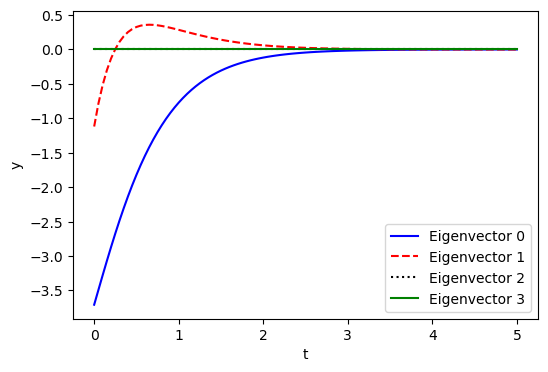

```python
s0 = sps.lti(A, B, C, [0]); ts = np.linspace(0,5,101); stys = ['b-', 'r--', 'k:', 'g-']

f = plt.figure(figsize=(6,4))
for _i in range(4):
    t, y, x = sps.lsim(s0, 0, ts, X0=Os[_i])
    plt.plot(t, y, stys[_i], label=f"Eigenvector {_i}")
    print(np.sum(y**2)*t[1])
plt.legend(); plt.xlabel('t'); plt.ylabel('y');
```

## Dual Systems

The primal

$$ \begin{align*} \dot{x} &= Ax+Bu \\ y &= Cx+Du \end{align*} $$

The dual

$$ \begin{align*} \dot{z} &= A^Tz+C^Tv \\ w &= B^Tz+D^Tv \end{align*} $$

[Ref: What Is the Adjoint of a Linear System?](https://dsbaero.engin.umich.edu/wp-content/uploads/sites/441/2020/05/Adjoints-21.pdf)

The observability/controllability matrices/gramians of the primal are ...

... the controllability/observability matrices/gramians of the dual

### Making sense of the dual (optional)

First think about a simple case, $$ \begin{align*} \min_y &\ J(u) = \beta^T u \\ \mathrm{s.t.} &\ y=Au \end{align*} $$ To find the **sensitivity** $dJ/dy$ - how to change $u$ to produce change in $y$. $$ \begin{align*} \cL(u,y,\lambda) &= J(u) + \lambda^T (y-Au) \\ \Rightarrow \frac{\partial\cL}{\partial u} &= \beta - A^T\lambda = 0 \end{align*} $$ Then $\lambda=A^{-T}\beta$, and $$ \frac{dJ}{dy} = \frac{\partial\cL}{\partial y} = \lambda $$ i.e., $\lambda$ is the sensitivity.

Now we extend the linear matrices and vectors to linear operators $$ \begin{align*} \min&\ J[u(t)] = <\beta(t), u(t)> \\ \mathrm{s.t.}&\ y(t) = \cA[u(t)] \end{align*} $$ where $$ <\beta, u> = \int_0^T \beta(t)^T u(t) dt,\quad \cA[u] = \int_0^t C\exp(A(t-\tau))Bu(\tau) d\tau + Du(t) $$

Work on the new Lagrangian $$ \begin{align*} \cL[u,y,\lambda] &= J[u] + <\lambda, y - \cA[u]> \\ \delta\cL &= <\beta,\delta u> - <\lambda, \cA[\delta u]> + <\lambda, \delta y> \\ &= <\beta,\delta u> - <\cA^T\lambda, \delta u> + <\lambda, \delta y> \\ &= <\beta - \cA^T\lambda, \delta u> + <\lambda, \delta y> \end{align*} $$ Then formally we get **sensitivity** $dJ/dy=\lambda$, with $\lambda=\cA^{-T}\beta$.

But what is $A^T$ in the sense of linear operator?

- This is the so-called **adjoint** operator.

For our particular case, we just manipulate the integral to find the adjoint $$ \begin{align*} <\lambda, \cA[\delta u]> &= \int_0^T \lambda(t)^T \left(\int_0^t C\exp(A(t-\tau))B\delta u(\tau) d\tau + D\delta u(t)\right) dt \\ &= \int_0^T \int_0^t \lambda(t)^T C\exp(A(t-\tau))B\delta u(\tau) d\tau dt + \int_0^T\lambda(t)^T D\delta u(t) dt \end{align*} $$ The second integral is easy to treat: $$ \int_0^T \left(D^T\lambda(t)\right)^T \delta u(t) dt $$ For the first one, note an identity: $$ \int_0^T\int_0^t f(t,\tau)d\tau dt = \int_0^T\int_\tau^T f(t,\tau)dtd\tau $$

Then the first integral becomes $$ \begin{align*} &\ \int_0^T \int_0^t \lambda(t)^T C\exp(A(t-\tau))B\delta u(\tau) d\tau dt \\ &= \int_0^T \int_\tau^T \lambda(t)^T C\exp(A(t-\tau))B\delta u(\tau) dt d\tau \\ &= \int_0^T \left(\int_\tau^T \lambda(t)^T C\exp(A(t-\tau))B dt\right) \delta u(\tau) d\tau \\ &= \int_0^T \left(\int_\tau^T B^T\exp(A^T(t-\tau))C^T \lambda(t) dt\right)^T \delta u(\tau) d\tau \\ &= \int_0^T \left(\int_t^T B^T\exp(A^T(\tau-t))C^T \lambda(\tau) d\tau\right)^T \delta u(t) dt \end{align*} $$ Note the swap of variable **names** in the end: $t\rightarrow \tau$, $\tau\rightarrow t$.

From the two integrals, we obtain $$ \cA^T\lambda = \int_t^T B^T\exp(A^T(\tau-t))C^T\lambda(\tau) d\tau + D^T\lambda(t) $$ Corresponds exactly to the dual system!

## Balancing Transformation

The concepts of Controllability and Observability are coordinate independent.

However, the Gramians are **not**.

Given a coordinate transformation $x'=Tx$, one can verify that the new Gramians are $$ \cP' = T\cP T^T,\quad \cQ' = T^{-T}\cQ T^{-1} $$

It would be a good idea to balance the two via a certain coordinate transformation.

The hope is to have the same magnitude (if possible) for $\norm{\cP'}$ and $\norm{\cQ'}$ (for a certain norm). This is equivalent to have $$ \min_T \mathrm{trace}(\cP'+\cQ') $$

It turns out the trace minimizes when $\cP'=\cQ'=\Sigma$, where $\Sigma$ is a diagonal matrix of **Hankel singular values**

> Hankel singular values are the SVs of $\cP\cQ$.

Algorithmically, we can find the balancing transformation by

- Cholesky factorization: $\cP=UU^T$, $\cQ=ZZ^T$
- SVD: $U^TZ=W\Sigma V^T$
- Then:

$$ T=\Sigma^{-1/2}V^TZ^T,\quad T^{-1}=UW\Sigma^{-1/2} $$

### Balanced truncation

The balancing transformation naturally gives us a coordinate system that

- The leading states are **both** the most controllable and observable.

As a result, we could truncate out the last states, that are the **least** controllable and observable.

In practice, just replace "SVD" with "truncated SVD" in the balancing transformation!

### Truncation error

Consider the transfer function for the linear system $Y(s)=G(s)U(s)$ $$ G(s) = C(sI-A)^{-1}B $$

Suppose we truncate the states, so that the system matrices become $(\tilde{A},\tilde{B},\tilde{C})$, then $$ \tilde{G}(s) = \tilde{C}(sI-\tilde{A})^{-1}\tilde{B} $$

A natural idea is to quantify the truncation error by $$ \norm{G(s)-\tilde{G}(s)} $$ But we need to choose the appropriate norm.

$G$ is a linear mapping from $U$ to $Y$.

- To quantify the "magnitude" of linear mapping, we have used the spectral norm $$ \norm{G}_2 = \max_{U} \frac{\norm{Y}_2}{\norm{U}_2} = \sigma_\max(G) $$
- But now $G$ is a function of complex variable $s$, so we extend to $H_\infty$ norm $$ \norm{G(s)}_{H_\infty} = \sup_{s} \norm{G(s)}_2 = \sup_s \sigma_\max(G(s)) $$

  > Approximately $\sup$ is like $\max$ - just for math rigor

Effectively this is equivalent to $$ \norm{G(s)}_{H_\infty} = \sup_u \sqrt{\frac{ \int_0^\infty\norm{y(t)}^2dt }{ \int_0^\infty\norm{u(t)}^2dt }} $$

In other words, we can quantify $$ \norm{G(s)-\tilde{G}(s)} $$ by the output error $$ \norm{y(t)-\tilde{y}(t)} $$ given the same input $u(t)$

Then we can find a formula that is very similar to truncated SVD: $$ \norm{G(s)-\tilde{G}(s)} \leq 2\sum_{i=r}^N \sigma_i $$ where $\sigma_i$ are the truncated distinct singular values.

### Problem of balanced truncation

Requires the computation of Gramians, which is $O(N^3)$ and hence expensive.

An alternative is the Balanced Proper Orthogonal Decomposition (BPOD).

[Rowley2005](https://cwrowley.princeton.edu/papers/bt_ijbc3.pdf)

The key idea is to note the impulse response with zero initial condition $$ x_i(t) = \exp(At)b_i $$ Then the controllability Gramian is approximated as $$ \cP = \int_0^\infty \sum_{i}^p x_i(t)x_i(t)^T dt \approx \sum_{j=1}^N \sum_{i}^p x_i(t_j)x_i(t_j)^T\Delta t \equiv XX^T $$

Similarly, if one has access to the dual system and obtain the impulse responses, then the observability Gramian is obtained as well. $$ \cQ\approx YY^T $$

```python
# Contr Gramian, standard vs. data-driven
P0 = comp_cP_inf(A, B)
P1 = comp_cP_approx(A, B)
print(np.linalg.norm(P0-P1)/np.linalg.norm(P0))

# Obser Gramian, standard vs. data-driven
Q0 = comp_cQ_inf(A, C)
Q1 = comp_cQ_approx(A, C)
print(np.linalg.norm(Q0-Q1)/np.linalg.norm(Q0))
```

```
0.034218825534171514
0.0317342309031413
```

Then one can just do $$ Y^TX = W\Sigma V^T $$ and the rest follows.

### Side comment

A conventional approach for model order reduction is by Proper Orthogonal Decomposition (i.e., without "balanced")

One just takes the impulse responses $X$ and perform (truncated) SVD $$ X = W\Sigma V^T $$ and assume the states are approximated by $$ x(t) = Wz(t) $$ so $$ \dot{x}=Ax+Bu \Rightarrow W\dot{z} = AWz + Bu \Rightarrow \dot{z} = W^TAWz + W^TBu $$ This is effectively picking $T=W^T$ and $T^{-1}=W$.

> But now we know simple POD is not the best choice!

### Example

```python
Tinv, T = bal_trunc((A,B,C))   # Balanced truncation
Ab, Bb, Cb = sys_transform((A,B,C), Tinv, T=T)
sys_print((Ab, Bb, Cb))
Ar, Br, Cr = np.array([[Ab[0,0]]]), np.array([[Bb[0,0]]]), np.array([[Cb[0,0]]])
```

```
[[-2.0000e+00 -9.2839e-12  1.6585e-08 -2.2667e-04  1.7321e+00]
 [ 1.7273e-04 -1.0000e+00 -8.7400e-04 -1.3968e-08 -7.4795e-05]
 [ 4.8527e-09 -2.2365e-04 -4.8423e+00 -1.8382e-04  1.2525e-08]
 [-1.0632e-04  6.8819e-01  1.4101e+04  5.3529e-01  4.0600e-05]
 [-1.7321e+00 -8.1855e-12  1.4363e-08 -1.9631e-04  0.0000e+00]]
```

```python
Tinv, T = cP_trunc((A,B,C), 1)  # POD
Ap, Bp, Cp = sys_transform((A,B,C), Tinv, T=T)
sys_print((Ap, Bp, Cp))
```

```
[[-1.6444  1.6019]
 [-1.6856  0.    ]]
```

```python
Tinv, T = bpod_trunc((A,B,C), 1)  # Balanced POD
Ad, Bd, Cd = sys_transform((A,B,C), Tinv, T=T)
sys_print((Ad, Bd, Cd))
```

```
[[-2.     -1.7321]
 [ 1.7321  0.    ]]
```

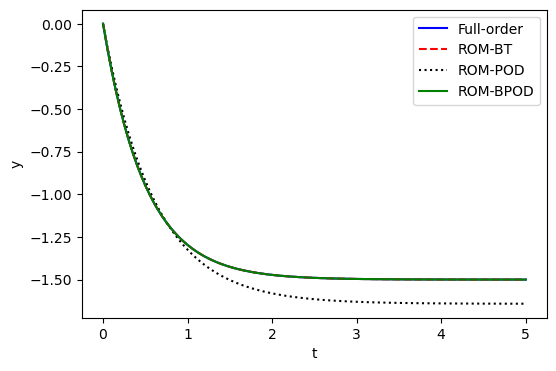

```python
f = plt.figure(figsize=(6,4))
for _i in range(4):
#     t, y = sps.impulse(ss[_i], T=ts)
    t, y = sps.step(ss[_i], T=ts)
    plt.plot(t, y, stys[_i], label=lbls[_i])
plt.legend()
plt.xlabel('t')
plt.ylabel('y');
```